# 1 Key Results

# 3 Mapping the Tech Cluster

1. count the frequency of tech firm grouped by `Laua`
2. import the spatial dataset `local authority boundary`
3. merge with `1.` and `2.` to visualise the spatial distribution

## 3.1 Detect the fame_OC data

drop the rows which contain NA value in the **laua** column

```python
print(df.shape)
df1 = df.copy()
df1 = df1.dropna(subset=["laua"])
print(df1.shape)
```

```
(513708, 64)
(502658, 64)
```

```python
df_laua = pd.read_csv(PATH + "/Dataset/Spatial/Local_Authority_2017.csv")
df_laua.head()
```

|  | objectid | lad17cd | lad17nm | lad17nmw | bng_e | bng_n | long | lat | st_areashape | st_lengthshape |
| --- | --- | --- | --- | --- | --- | --- | --- | --- | --- | --- |
| 0 | 1 | E06000001 | Hartlepool |  | 447157 | 531476 | -1.27023 | 54.676159 | 9.355951e+07 | 71707.407523 |
| 1 | 2 | E06000002 | Middlesbrough |  | 451141 | 516887 | -1.21099 | 54.544670 | 5.388858e+07 | 43840.866561 |
| 2 | 3 | E06000003 | Redcar and Cleveland |  | 464359 | 519597 | -1.00611 | 54.567520 | 2.448203e+08 | 97993.391012 |
| 3 | 4 | E06000004 | Stockton-on-Tees |  | 444937 | 518183 | -1.30669 | 54.556911 | 2.049622e+08 | 119581.595543 |
| 4 | 5 | E06000005 | Darlington |  | 428029 | 515649 | -1.56835 | 54.535351 | 1.974757e+08 | 107206.401694 |

```python
# df_laua = pd.read_csv(PATH + "/Dataset/ttwa.csv")
df_laua_10 = pd.DataFrame(df1.laua.value_counts()[:12]).reset_index()
df_laua_10.columns = ["laua_code","count"]

df_laua_10 = pd.merge(df_laua_10, df_laua[["lad17cd","lad17nm"]], left_on="laua_code",right_on="lad17cd")

df_laua_10 = df_laua_10[["laua_code","count","lad17nm"]]
df_laua_10.columns = ["laua_code","count","name"]
df_laua_10.style
```

|  | laua_code | count | name |
| --- | --- | --- | --- |
| 0 | E09000007 | 15897 | Camden |
| 1 | E09000033 | 12069 | Westminster |
| 2 | E09000012 | 12036 | Hackney |
| 3 | E09000019 | 10271 | Islington |
| 4 | E06000043 | 8026 | Brighton and Hove |
| 5 | E08000025 | 7356 | Birmingham |
| 6 | E09000003 | 7023 | Barnet |
| 7 | E08000003 | 6254 | Manchester |
| 8 | E08000035 | 5899 | Leeds |
| 9 | E09000001 | 5576 | City of London |

## 3.2 Import the laua spatial info

This file is `Local_Authority_2019_Boundaries/Local_Authority_Districts_(December_2019)_Boundaries_UK_BFC.shp`

```python
# read the shape file and plot map

import geopandas as gpd
g_laua = gpd.read_file(PATH + "/Dataset/Spatial/Local_Authority_2019_Boundaries/Local_Authority_Districts_(December_2019)_Boundaries_UK_BFC.shp")
print(g_laua)
```

```
     objectid    lad19cd               lad19nm        lad19nmw   bng_e  \
0           1  E06000001            Hartlepool            None  447160
1           2  E06000002         Middlesbrough            None  451141
2           3  E06000003  Redcar and Cleveland            None  464361
3           4  E06000004      Stockton-on-Tees            None  444940
4           5  E06000005            Darlington            None  428029
..        ...        ...                   ...             ...     ...
377       378  W06000020               Torfaen         Torfaen  327459
378       379  W06000021         Monmouthshire       Sir Fynwy  337812
379       380  W06000022               Newport       Casnewydd  337897
380       381  W06000023                 Powys           Powys  302329
381       382  W06000024        Merthyr Tydfil  Merthyr Tudful  305916

      bng_n     long        lat    st_areasha     st_lengths  \
0    531474 -1.27018  54.676140  9.371262e+07   71011.933949
```

[output cut: 25 more lines]

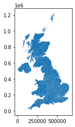

```python
g_laua.plot()
```

## 3.3 Merge the spatial and info

get the laua and frequency list and transform into the frequency

```python
df_laua_freq = pd.DataFrame(df1.laua.value_counts()).reset_index()
df_laua_freq.columns = ["laua_code","count"]
df_laua_freq.head()
```

|  | laua_code | count |
| --- | --- | --- |
| 0 | E09000007 | 15897 |
| 1 | E09000033 | 12069 |
| 2 | E09000012 | 12036 |
| 3 | E09000019 | 10271 |
| 4 | E06000058 | 9437 |

merge the `df_laua_freq` and `g_laua`

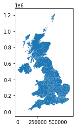

```python
df_laua_mg = pd.merge(g_laua, df_laua_freq,left_on='lad19cd',right_on='laua_code',how='inner').reset_index()
df_laua_mg.plot()
```

cmap settings ref: https://matplotlib.org/stable/tutorials/colors/colormaps.html

## 3.4 Mapping the Freuqency

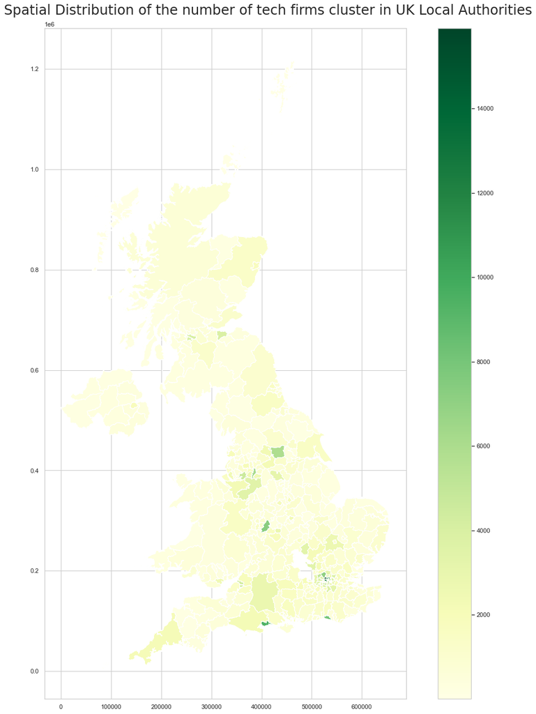

```python
import pysal as ps
import numpy as np
import pandas as pd
import seaborn as sns
import geopandas as gpd
import matplotlib.pyplot as plt

tfont = {'fontname':'DejaVu Sans', 'horizontalalignment':'left'}
f1 = plt.figure()
f1.set_size_inches(20,20)

ax1 = f1.add_subplot()
df_laua_mg.plot(column='count', legend=True, cmap='YlGn', ax=ax1)
# df_laua_mg.plot(column='count', legend=True, cmap='plasma',figsize=(180,60),ax=ax1)

f1.subplots_adjust(top=0.95)
# f1.suptitle(f"Frequency Distribution of tech firms cluster by Local Authorities", x=0.025, size=24, **tfont)
f1.suptitle(f"Spatial Distribution of the number of tech firms cluster in UK Local Authorities", x=0.25, size=24, **tfont)
f1.savefig(PATH+'/Img/Frequency_Distribution_of_tech_firms_cluster_by_LAUA.png', dpi=300)
```

## 3.5 Plot the Bar Chart

```python
df_laua_10.style
```

|  | laua_code | count | name |
| --- | --- | --- | --- |
| 0 | E09000007 | 15897 | Camden |
| 1 | E09000033 | 12069 | Westminster |
| 2 | E09000012 | 12036 | Hackney |
| 3 | E09000019 | 10271 | Islington |
| 4 | E06000043 | 8026 | Brighton and Hove |
| 5 | E08000025 | 7356 | Birmingham |
| 6 | E09000003 | 7023 | Barnet |
| 7 | E08000003 | 6254 | Manchester |
| 8 | E08000035 | 5899 | Leeds |
| 9 | E09000001 | 5576 | City of London |

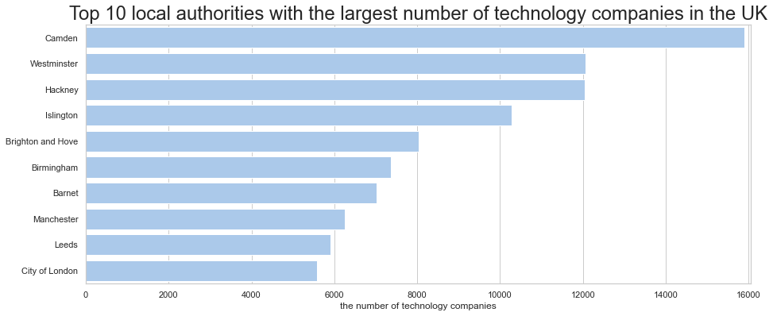

```python
import seaborn as sns
import matplotlib.pyplot as plt
sns.set_theme(style="whitegrid")

# Initialize the matplotlib figure
f2, ax2 = plt.subplots(figsize=(15,6))

# Load the example car crash dataset
# crashes = sns.load_dataset("car_crashes").sort_values("total", ascending=False)

# Plot the total crashes
sns.set_color_codes("pastel")
sns.barplot(x="count", y="name", data=df_laua_10, color="b")

# Add a legend and informative axis label
# ax.legend(ncol=2, loc="lower right", frameon=True)
ax2.set(xlim=(0, 16050), ylabel="", xlabel="the number of technology companies")
ax2.set_title("Top 10 local authorities with the largest number of technology companies in the UK",fontsize = 24)
# sns.despine(left=True, bottom=True)
f2.savefig(PATH + "/Img/The_Top_10_Number_of_Tech_Firms.png")
```

# 4 Explore the Movers

For `fame_OC`

1. keep the same name before and after movement
2. change the name before and after movement

```python
df2 = df.copy()
firm_name_freq = pd.DataFrame(df2.normalised_name.value_counts()).reset_index()
firm_name_freq.columns = ["firm_name","count"]

# firm's name re-appears
firm_name_re = firm_name_freq[firm_name_freq["count"]>1]
firm_name_re.style
```

|  | firm_name | count |
| --- | --- | --- |
| 0 | plexus holdings plc | 4 |
| 1 | rhythmone plc | 4 |
| 2 | mcguirk industries limited | 2 |
| 3 | create limited | 2 |
| 4 | solutions design limited | 2 |
| 5 | synthesizedesign limited | 2 |
| 6 | multiconnect limited | 2 |
| 7 | ja richardson engineering limited | 2 |
| 8 | entertainment international limited | 2 |
| 9 | globex corporation limited | 2 |
| 10 | bloody surgery limited | 2 |
| 11 | dwm media limited | 2 |
| 12 | jc film limited | 2 |
| 13 | sar uk limited | 2 |
| 14 | kcom group plc | 2 |
| 15 | jkl tribe limited | 2 |
| 16 | bucks cbt plus limited | 2 |
| 17 | conversion company limited | 2 |
| 18 | proact it uk limited | 2 |
| 19 | access it resource limited | 2 |
| 20 | ready player one limited | 2 |
| 21 | nmr geosciences limited | 2 |
| 22 | grace and grace limited | 2 |
| 23 | amd tech limited | 2 |
| 24 | red red limited | 2 |
| 25 | we unicorns limited | 2 |
| 26 | quality care solutions limited | 2 |
| 27 | future corporation limited | 2 |
| 28 | ctrl z limited | 2 |
| 29 | gopher it support limited | 2 |
| 30 | jd software limited | 2 |
| 31 | cliste consulting limited | 2 |
| 32 | sri corporation limited | 2 |
| 33 | eye clinic limited | 2 |
| 34 | hit reset limited | 2 |
| 35 | agility limited | 2 |
| 36 | acm transport limited | 2 |
| 37 | mak corporation limited | 2 |
| 38 | hive limited | 2 |
| 39 | limited | 2 |
| 40 | mind music limited | 2 |
| 41 | anlex8 limited | 2 |

Then back to the `fame_OC` and filter these possible movers

```python
df_fame_movers = df.copy()
df_fame_movers = df_fame_movers[df_fame_movers.normalised_name.isin(firm_name_re.firm_name.to_list())]
# df_fame_movers.to_csv(PATH + "/df_fame_OC_movers.csv")
```

```python
# detect which one has different postcode in the same normalised name
df_movers = pd.DataFrame(df_fame_movers.groupby("normalised_name")["postcode"].nunique()).reset_index()
# more than 2 distinct postcodes mean these tech firms may move
df_movers = df_movers[df_movers["postcode"]>=2]
```

[output not shown]

```python
# export a list that tech firm have different postcode while they have the same names
df_movers_1 = df_fame_movers[df_fame_movers["normalised_name"].isin(df_movers["normalised_name"].to_list())]
possible_tech_movers = df_movers_1[["registered_number","incorporation_date","dissolution_date","normalised_name","postcode"]].sort_values(by="normalised_name")
possible_tech_movers
```

|  | registered_number | incorporation_date | dissolution_date | normalised_name | postcode |
| --- | --- | --- | --- | --- | --- |
| 164178 | 3060979 | 1995-05-24 | NaN | agility limited | EN49HN |
| 144252 | 07418654 | 2010-10-25 | NaN | agility limited | EC1V2NX |
| 279459 | 11632107 | 2018-10-19 | NaN | amd tech limited | N156RH |
| 182708 | 06250619 | 2007-05-17 | NaN | amd tech limited | GL53PN |
| 228143 | 08424152 | 2013-02-28 | NaN | conversion company limited | KT70RY |
| 512012 | 1981640 | 1986-01-23 | NaN | conversion company limited | YO211QL |
| 157297 | SC583384 | 2017-12-07 | NaN | create limited | EH107DU |
| 285768 | 7460781 | 2010-12-06 | NaN | create limited | N17GU |
| 20379 | 11059998 | 2017-11-13 | NaN | ctrl z limited | BA113EE |
| 469818 | 05608171 | 2005-11-01 | NaN | ctrl z limited | W1T6AD |
| 213430 | 11634444 | 2018-10-22 | NaN | entertainment international limited | IG110GH |
| 323343 | 11143790 | 2018-01-10 | NaN | entertainment international limited | NW51EN |
| 12019 | 8070874 | 2012-05-16 | NaN | eye clinic limited | B288EZ |
| 211689 | 06219671 | 2007-04-19 | NaN | eye clinic limited | HU53TS |
| 140510 | 7744742 | 2011-08-18 | NaN | future corporation limited | E83DL |
| 39534 | 5631136 | 2005-11-21 | NaN | future corporation limited | BL26RT |
| 271030 | 04397427 | 2002-03-18 | NaN | globex corporation limited | MK428TU |
| 19904 | 09552070 | 2015-04-21 | NaN | globex corporation limited | B976HR |
| 387395 | 11065921 | 2017-11-15 | NaN | grace and grace limited | SE64EJ |
| 241453 | 11412829 | 2018-06-13 | NaN | grace and grace limited | LL116UG |
| 47123 | 8546782 | 2013-05-28 | NaN | hit reset limited | BN16AF |
| 224545 | 6598405 | 2008-05-20 | NaN | hit reset limited | KT168PD |
| 242014 | 3937810 | 2000-03-01 | NaN | hive limited | LL181RF |
| 511527 | 10797308 | 2017-06-01 | NaN | hive limited | YO126HT |
| 291684 | 10589202 | 2017-01-30 | NaN | jc film limited | N32JU |
| 143676 | 11613438 | 2018-10-09 | NaN | jc film limited | EC1R0DU |
| 424940 | 9549356 | 2015-04-19 | NaN | jd software limited | SW152BF |
| 72656 | 04405957 | 2002-03-28 | NaN | jd software limited | CB249AD |
| 133614 | 11306057 | 2018-04-12 | NaN | limited | E162DQ |
| 326148 | 10219186 | 2016-06-07 | NaN | limited | NW99NL |
| 8204 | 7998847 | 2012-03-20 | NaN | mak corporation limited | B112AA |
| 39799 | 10674075 | 2017-03-16 | NaN | mak corporation limited | BL35AZ |
| 323418 | 9252531 | 2014-10-07 | NaN | mind music limited | NW51UA |
| 153204 | 09331890 | 2014-11-28 | NaN | mind music limited | EC2R6AY |
| 192884 | 9989675 | 2016-02-05 | NaN | quality care solutions limited | HA12SP |
| 407150 | 7745467 | 2011-08-18 | NaN | quality care solutions limited | SN33AJ |
| 33981 | 11438196 | 2018-06-28 | NaN | red red limited | BH149NY |
| 215822 | 11233132 | 2018-03-05 | NaN | red red limited | IG45HQ |
| 332492 | 6329371 | 2007-07-31 | NaN | sar uk limited | OX46NG |
| 268281 | 8922191 | 2014-03-04 | NaN | sar uk limited | MK11SW |
| 180039 | 05549948 | 2005-08-31 | NaN | solutions design limited | GL170PZ |
| 494527 | 11567756 | 2018-09-13 | NaN | solutions design limited | WC2H9JQ |
| 368604 | 8417509 | 2013-02-25 | NaN | sri corporation limited | S117AQ |
| 398016 | 8817694 | 2013-12-17 | NaN | sri corporation limited | SL11UA |
| 151594 | 11487977 | 2018-07-27 | NaN | we unicorns limited | EC2A4NE |
| 491599 | 9732240 | 2015-08-13 | NaN | we unicorns limited | WC2H7LA |